# Homework_tdistribution

Carlos Rodriguez

10/11/2017

1. Let’s begin practicing real data analysis: look at, plot, and analyze the data as required below. Please describe the data, your analysis, and your findings using complete sentences. Use the data set named email found on my website; the README will help you learn about / describe the data.
1. Calculate and interpret a 90% confidence interval for the proportion of emails that have more than one line break. Hint, you must first create the variable of interest.

```r
email <-read.csv("http://roualdes.us/data/email.csv")
suppressMessages(library(ggplot2))
n <- sum(email$line_breaks>1)
##n
phat <- mean(email$line_breaks>1)
s <- sd(email$line_breaks>1)
##phat
##s
tstar <- qt(c(.05,.95), df=n-1)
phat+tstar*s/sqrt(n)
```

```
## [1] 0.9988964 1.0000834
```

We are 90% confident that the proportion of emails that have more than one line break is between .998 and 1.

2. Formally test to see if the mean number of line breaks in emails is equal to 250, use α = 0.05.

```r
phat <- mean(email$line_breaks)
##phat
s <- sd(email$line_breaks)
s
```

```
## [1] 319.305
```

```r
n <- length(email$line_breaks)
t <- (phat-250)/(s/sqrt(n))
##t
2*(1-pt(abs(t), n-1))
```

```
## [1] 0.0001510817
```

```r
2*(1-pnorm(abs(t)))
```

```
## [1] 0.0001488384
```

We reject the null hypothesis. This makes our results significant.

3. Calculate and interpret a 95% confidence interval for the mean number of line breaks in emails.

[output not shown]

We are 95% confident that the mean number of line breaks in emails is between 220 and 240.

4. Does your confidence interval match the conclusion from your hypothesis test?

Yes the average from our hypothesis was thought to be 250 which we rejected this null hypothesis. It turns out our mean number of line breaks with our confidence interval is between 220 and 240 line breaks.

5. What does the confidence interval tell you that the hypothesis test does not?

The confidence interval can tell us an estimate of a range where the parameter may lie. You will be able to make infereneces from the interval and a hypothesis test is just lets you know whether to reject the null.

6. Describe at least three things about email 1771, using complete sentences.

```r
email[1771,]
```

```
##      spam to_multiple from cc sent_email                time image attach
## 1771    0           0    1  0          0 2012-02-10 09:21:09     0      0
##      dollar winner inherit viagra password num_char line_breaks format
## 1771     44     no       0      0        0  190.087        4022      1
##      re_subj exclaim_subj urgent_subj exclaim_mess number
## 1771       0            0           0         1236    big
```

7. Make and describe appropriate plots for the two random variables above; the proportion of emails that have more than one line break and the number of line breaks.

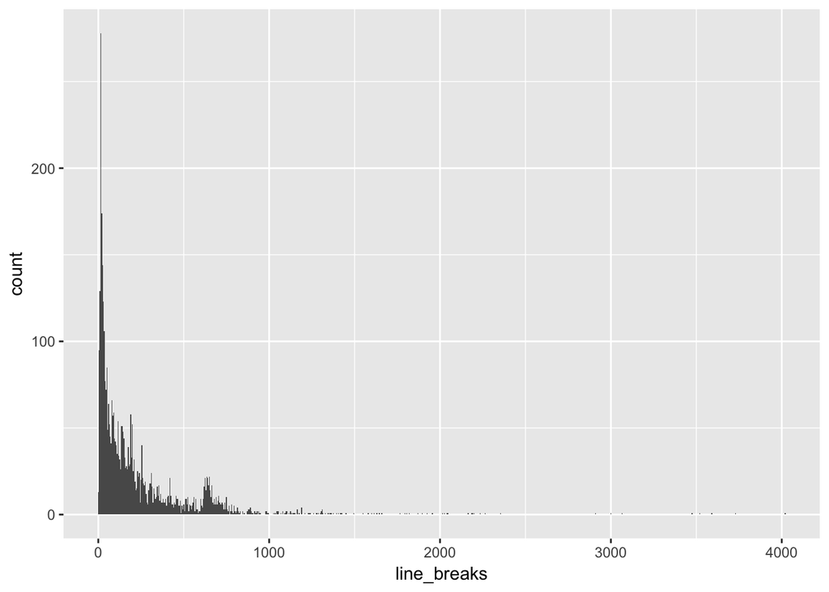

```r
library(ggplot2)
qplot(line_breaks, data=email, geom="histogram", binwidth=5)
```

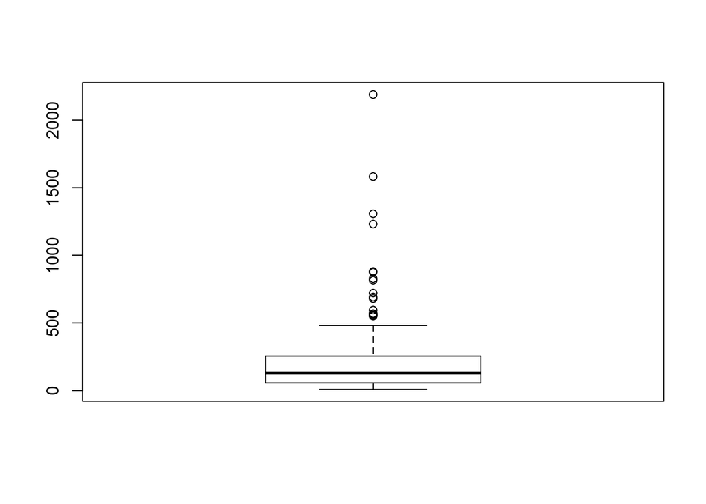

```r
boxplot(email$line_breaks[1:200])
```

8. Is the mean or median more appropriate for the number of line breaks in emails? Justify your reasoning.

```r
mean(email$line_breaks)
```

```
## [1] 230.6585
```

```r
median(email$line_breaks)
```

```
## [1] 119
```

I believe the mean median is a more appropriate number for the number of line breaks in emails because the mean was affected by the few emails that had a signficant amount of line breaks like email 1771. Which i believe had the highest amount of line breaks that was a lone number with a huge difference where most emails lie.

2. A 95% confidence interval for a population mean is given as (18.985, 21.015). This confidence interval is based on a simple random sample of 36 observations. Calculate the sample mean and standard deviation. Use the t-distribution in any calculations.

```r
n <- 36
tstar <- qt(c(.025,.975),df=n-1)
ci <- c(18.985,21.015)
xbar <- mean(c(18.985,21.015))
xbar
```

```
## [1] 20
```

```r
(sqrt(n)*(ci-xbar))/tstar
```

```
## [1] 2.999841 2.999841
```

The mean is 20 and the standard deviation is 3.